# Reto 7: Ruido en la ciudad de Cali

## Contexto

La calidad de vida en las ciudades es un tema de gran importancia para el bienestar de sus habitantes, uno de los grandes problemas en las grandes ciudades como Cali es la contaminación auditiva, en especial el centro de la ciudad debido al trafico vehicular constante, la actividad comercial, obras en construcción, la alta densidad poblacional, arquitectura de la zona, entre otros factores. Este puede causar un efecto en la salud a largo plazo en sus habitantes y visitantes frecuentes en la zona, como problemas en la audición, el aumento del estrés, problemas de sueño y serios problemas cognitivos. Adicionalmente, se ha mostrado que en los lugares con un alto nivel de ruido se presentan fuertes problemas de convivencia y de comunicación entre las personas ya que aumenta la agresividad y la irritabilidad.

De esta forma estudiar la generación del ruido y buscar soluciones para mitigar este problema es un tema de gran importancia para la alcaldía de la ciudad de Cali, para ello, lo primero que se considera es identificar cuales son las zonas del centro de la ciudad con mayor nivel de ruido y determinar el tiempo en que este fenómeno sucede. Para llevar a acabo esta tarea, se ha identificado que el uso de las funciones trigonométricas puede ser de gran ayuda para modelar el comportamiento del ruido en distintos momentos del día.

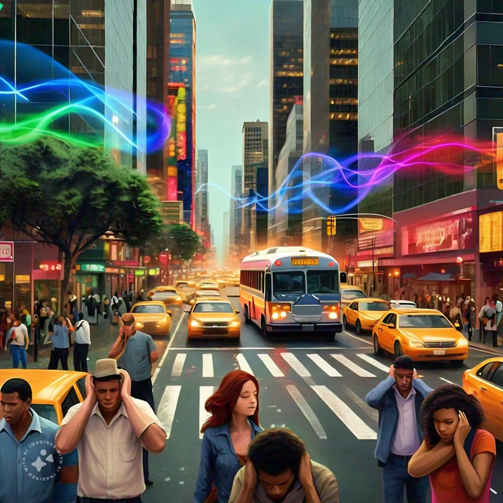

reto7.jpeg

### Objetivo general

Modelar el comportamiento del ruido utilizando una función trigonométrica que represente las fluctuaciones periódicas de los niveles de ruido a lo largo del día.

### Objetivos específicos

- Construir las funciones trigonométricas básicas.
- Graficar las funciones trigonométricas básicas e identificar sus propiedades.
- Modelar el comportamiento del ruido utilizando una función trigonométrica.

### Funciones trigonometricas básicas

Las funciones trigonometricas son funciones básicas que permiten relacional medidas de ángulos y lados en un triángulo rectángulo. Las funciones trigonometricas básicas son:

- Seno
- Coseno
- Tangente

Estas funciones son periódicas, es decir, se repiten en intervalos regulares. La función seno y coseno tienen un periodo de 2π, mientras que la función tangente tiene un periodo de $\pi$.

### Función trigonométricas desde el circulo trigonometrico

Las funciones trigonometricas se pueden definir a partir de un circulo trigonometrico. En el circulo trigonometrico, el radio es igual a 1, y el ángulo se mide en sentido contrario a las manecillas del reloj.

La proyección del punto P sobre el eje x es el coseno del ángulo, y la proyección sobre el eje y es el seno del ángulo.

### $\sin(\theta)$

[figure not shown]

### $\cos(\theta)$

[figure not shown]

### $\tan(\theta)$

[figure not shown]

```python
import requests
# URL del archivo
url = "https://raw.githubusercontent.com/abelalv/PUJ_MMAF/main/libreria7.py"
# Descargar el archivo
response = requests.get(url)
with open('libreria7.py', 'w') as file:
    file.write(response.text)

import libreria7 as li
```

```python
import numpy as np
import libreria7 as li
from ipywidgets import interact


# Crear el slider interactivo para el ángulo y las hipotenusas
interact(li.plot_two_triangles,
         angle_radians=(0, np.pi/2, np.pi/36),
         hypotenuse1=(0.5, 2.0, 0.1),
         hypotenuse2=(0.5, 2.0, 0.1))
```

```
<function libreria7.plot_two_triangles(angle_radians, hypotenuse1, hypotenuse2)>
```

### Periocidad de la funciones trigonométricas

Se define una función periocidad si satisface la siguiente expresión

$$f(t+T)=f(t)$$

donde $T$ es el periodo de la función. Las funciones trigonométricas son periódicas esto quiere decir, que se repiten en intervalos regulares. La función seno y coseno tienen un periodo de 2π, mientras que la función tangente tiene un periodo de π.

```python
import libreria7 as li
import numpy as np
import matplotlib.pyplot as plt
from ipywidgets import interact, FloatSlider
# Crear deslizador para controlar el desfase entre 0 y 4π
desfase_slider = FloatSlider(min=0, max=4 * np.pi, step=0.1, value=0, description='Desfase')

# Crear la interacción con el deslizador
interact(li.plot_sine, desfase=desfase_slider)
```

```
<function libreria7.plot_sine(desfase=0)>
```

### Gráficas de la función trigonometricas

La función $\sin\theta$ se puede escribir de la forma

$$f(\theta)=A\sin(B\theta+C)+D,$$

donde los parámetros: A, B, C y D son números reales y se puede interpretar como

- A como la amplitud de la función,
- B como la frecuencia de la función,
- C como el desplazamiento horizontal de la función,
- D como el desplazamiento vertical de la función.

```python
import libreria7 as li
import numpy as np
from ipywidgets import interact, FloatSlider

# Crear deslizadores interactivos para la amplitud, frecuencia, desfase y término constante
interact(li.graficar_seno,
         amplitud=(1, 10, 0.1),
         frecuencia=(0.1, 5, 0.1),
         desfase=(-np.pi, np.pi, 0.1),
         constante=(-5, 5, 0.1));
```

```python
import libreria7 as li
import numpy as np
from ipywidgets import interact, FloatSlider



# Crear deslizadores interactivos para la amplitud, frecuencia, desfase y término constante
interact(li.graficar_coseno,
         amplitud=(1, 10, 0.1),
         frecuencia=(0.1, 5, 0.1),
         desfase=(-np.pi, np.pi, 0.1),
         constante=(-5, 5, 0.1));
```

```python
import libreria7 as li
from ipywidgets import interact, FloatSlider


# Crear deslizadores interactivos para la amplitud, frecuencia, desfase y término constante
interact(li.graficar_tangente,
         amplitud=(1, 5, 0.1),
         frecuencia=(0.1, 5, 0.1),
         desfase=(-np.pi, np.pi, 0.1),
         constante=(-5, 5, 0.1));
```

### Nota

Observe que la función $\cos\theta$ es igual a la función $\sin\theta$ pero con un desplazamiento de $\frac{\pi}{2}$.

Esto lo podemos visualizar en la siguiente función

```python
import libreria7 as li
import numpy as np
from ipywidgets import interact, FloatSlider




# Crear deslizador interactivo para controlar el desfase de la función seno
interact(li.graficar_seno_desfase, desfase=(-2*np.pi, 2*np.pi, 0.1));
```

### Implementación de la función seno, coseno y tangente en Python

Las funciones trigonometricas se pueden implementar en Python utilizando el módulo `numpy` o `math`. A continuación se muestra un ejemplo de como se puede implementar la función seno, coseno y tangente en Python.

Si usamos la primera debemos importar el módulo `numpy` y si usamos la segunda debemos importar el módulo `math`.

```python
import numpy as np
```

o

```python
import math as mt
```

Recuerde que estas funciones reciben el ángulo en radianes. Si desea convertir de grados a radianes puede utilizar la siguiente fórmula:

$$\text{radianes} = \text{grados} \times \frac{\pi}{180}$$

desde python puede hacer la conversión de la siguiente manera:

```python
radianes = grados * np.pi / 180
```

para hallar el valor de un solo punto de una función usando la función seno, coseno o tangente, puede hacerlo de la siguiente manera:

```python
import numpy as np

angulo = np.pi/4
seno = np.sin(angulo)
```

o

```python
import math as mt

angulo = np.pi/4
seno = mt.sin(angulo)
```

para crear una grafica de la función seno, coseno o tangente, puede hacerlo de la siguiente manera:

```python
import numpy as np  # importa librerias
import matplotlib.pyplot as plt # importa librerias para graficas

x = np.linspace(-2*np.pi, 2*np.pi, 1000) # crea un arreglo de 1000 puntos entre -2pi y 2pi
y = np.sin(x) # calcula el seno de cada punto

plt.plot(x, y) # grafica x vs y
plt.show()  # muestra la grafica
```

```python
import numpy as np  # importa librerias
import matplotlib.pyplot as plt # importa librerias para graficas

x = np.linspace(-2*np.pi, 2*np.pi, 1000) # crea un arreglo de 1000 puntos entre -2pi y 2pi
y = np.sin(x) # calcula el seno de cada punto

plt.plot(x, y) # grafica x vs y
plt.grid()  # muestra la cuadricula
plt.title("Función seno")  # titulo de la grafica
plt.xlabel("x")  # etiqueta eje x
plt.ylabel("y")  # etiqueta eje y
plt.show()  # muestra la grafica
```

[figure not shown]

```python
## Grafica de las funciones seno y coseno  en el mismo plano

import numpy as np
import matplotlib.pyplot as plt

x = np.linspace(-2*np.pi, 2*np.pi, 1000)
y1 = np.sin(x)
y2 = np.cos(x)


plt.plot(x, y1, label='sin(x)')
plt.plot(x, y2, label='cos(x)')


plt.legend()
plt.show()
```

[figure not shown]

```python
## Grafica de las funciones seno y coseno  en el mismo plano
# Gráfico de tan(x)

import numpy as np
import matplotlib.pyplot as plt

plt.plot(x, np.tan(x), label=r"$\tan(x)$", color='purple', linewidth=2)
plt.axhline(0, color='black',linewidth=1)
plt.axvline(x=0, color='black',linewidth=1)
plt.ylim(-10, 10)
plt.title(r"Gráfica de $\tan(x)$", fontsize=16)
plt.xticks([-2 * np.pi, -3 * np.pi / 2, -np.pi, -np.pi / 2, 0, np.pi / 2, np.pi, 3 * np.pi / 2, 2 * np.pi],
           [r'$-2\pi$', r'$-\frac{3\pi}{2}$', r'$-\pi$', r'$-\frac{\pi}{2}$', '0', r'$\frac{\pi}{2}$', r'$\pi$', r'$\frac{3\pi}{2}$', r'$2\pi$'])
plt.grid(True)
plt.legend()

# Ajustar el espacio entre subplots
plt.tight_layout()

# Mostrar la gráfica
plt.show()
```

[figure not shown]

### Otras funciones trigonometricas

La funcion secante, cosecante y cotangente son funciones trigonometricas que se definen en terminos de las funciones trigonometricas básicas.

### $\sec(\theta) = \frac{1}{\cos(\theta)}$

### $\csc(\theta) = \frac{1}{\sin(\theta)}$

### $\cot(\theta) = \frac{1}{\tan(\theta)}$

```python
# Importar la función desde el módulo
import libreria7 as li

# Llamar a la función para graficar
li.graficar_funciones_trigonometricasotras()
```

[figure not shown]

### Identidades trigonometricas

Las identidades trigonométricas son ecuaciones que son verdaderas para cualquier valor del ángulo, siempre que los lados de la ecuación estén definidos. Estas identidades juegan un papel crucial en la simplificación de expresiones trigonométricas y en la resolución de ecuaciones trigonométricas.

## Identidades Básicas

Una de las identidades fundamentales que deriva directamente del círculo unitario es la **identidad pitagórica**, la cual establece que para cualquier ángulo $\theta$:

$$\sin^2(\theta) + \cos^2(\theta) = 1$$

Esta identidad nos dice que, al sumar los cuadrados de las funciones seno y coseno de un ángulo, siempre obtenemos 1.

### Ejercicios

1. Divide la identidad pitagorica por $\sin(\theta)$ y por $\cos(\theta)$, y obtén las siguientes identidades:

$$\tan^2(\theta) + 1 = \sec^2(\theta)$$

$$1 + \cot^2(\theta) = \csc^2(\theta)$$

### Identidades de Ángulos Complementarios

Otra identidad importante está relacionada con los ángulos complementarios. Dos ángulos son complementarios si suman $90^\circ$ (o $\frac{\pi}{2}$ radianes). Para un ángulo $\theta$, se tiene que:

$$\sin(90^\circ - \theta) = \cos(\theta) \quad \text{y} \quad \cos(90^\circ - \theta) = \sin(\theta)$$

Estas identidades muestran la relación inversa entre las funciones seno y coseno para ángulos complementarios.

### Identidades de Suma y Diferencia de Ángulos

Las identidades de suma y diferencia de ángulos son útiles cuando se trabaja con combinaciones de ángulos. Por ejemplo, para dos ángulos $A$ y $B$:

$$\sin(A \pm B) = \sin(A) \cos(B) \pm \cos(A) \sin(B)$$
$$\cos(A \pm B) = \cos(A) \cos(B) \mp \sin(A) \sin(B)$$

Estas fórmulas nos permiten expresar el seno y coseno de la suma o la diferencia de dos ángulos en términos de las funciones seno y coseno de los ángulos individuales.

En la siguiente simulación podemos observar como se satisface la identidad para cualquier angulo $\theta$.

```python
from ipywidgets import interact

import libreria7 as li

# Crear un deslizador para interactuar con el ángulo
interact(li.identidad_pitagorica, theta_deg=(0, 360, 1));
```

Con la librería ‘sympy’ podemos comprobar que algunas de las identidades trigonométricas son verdaderas. A continuación se muestra un ejemplo de como se puede comprobar la identidad trigonométrica,

$$\sin^2(\theta) + \cos^2(\theta) = 1,$$

Para ello usamos la función `simplify` de la librería `sympy` que simplifica la expresión matemática.

```python
import sympy as sp

x= sp.symbols('x')
identidad_1 = sp.sin(x)**2 + sp.cos(x)**2
identidad_2 = 1
sp.simplify(identidad_1 - identidad_2)
```

[output not shown]

si arroja 0, la identidad es verdadera, en otro contrario es falsa.

Note que en este caso debemos usar las funciones `sin` y `cos` de la librería `sympy`, es decir para llamarlas debemos usar `sp.sin` y `sp.cos`.

### Funciones inversas

Recuerde que para construir una función inversas se necesita la función sea inyectiva y sobreyectiva, como podemos ver en el caso de la función $\sin\theta$ no cumple estas propiedades, por tanto no tiene una función inversa, pero para construir una función inversa debemos restringir el dominio de la función $\sin\theta$, para que cumpla las propiedades necesarias para tener una función inversa. Por tanto,en el caso de la función $\sin\theta$ se restringe entre el intervalo

$$\Big[-\frac{\pi}{2},\frac{\pi}{2}\Big],$$

y es denotada como $\sin^{-1}\theta$ o $\arcsin\theta$.

En el caso del coseno se restringe entre el intervalo

$$\Big[0,\pi\Big],$$

y es denotada como $\cos^{-1}\theta$ o $\arccos\theta$.

En el caso de la tangente se restringe entre el intervalo

$$\Big[-\frac{\pi}{2},\frac{\pi}{2}\Big],$$

y es denotada como $\tan^{-1}\theta$ o $\arctan\theta$.

A continuación mostraremos la gráfica de la función $\sin^{-1}\theta$, $\cos^{-1}\theta$ y $\tan^{-1}\theta$

```python
import libreria7 as li
import numpy as np
import matplotlib.pyplot as plt
from ipywidgets import interact


# Ejecutar la función para graficar
li.graficar_inversas()
```

[figure not shown]

### Ecuaciones Trigonometricas

Las ecuaciones trigonometricas son ecuaciones que involucran funciones trigonometricas. Estas ecuaciones se pueden resolver utilizando las propiedades de las funciones trigonometricas y las identidades trigonometricas.

```python
import libreria7 as li
import numpy as np
import matplotlib.pyplot as plt
from ipywidgets import interact



# Crear un deslizador para interactuar con el valor de A
interact(li.resolver_seno, A=(-1, 1, 0.1));
```

```python
import libreria7 as li
import numpy as np
import matplotlib.pyplot as plt



# Llamar a la función para graficar
li.graficar_funcion_trigonometrica()
```

[figure not shown]

## Conexión con el reto

### Como podemos estudiar el sonido usando las funciones trigonométricas

## Contexto

En esta experiencia, vamos a modelar la temperatura promedio anual en un país con estaciones usando ondas sinusoidales. Las estaciones del año, como invierno, primavera, verano y otoño, afectan las temperaturas, las cuales pueden variar de manera predecible. Usaremos una función sinusoidal para representar esta variación de temperatura a lo largo del año.

La fórmula que utilizaremos es:

$$T(t) = A \cdot \sin\left( \frac{2 \pi}{P} \cdot (t - \phi) \right) + C$$

Vamos a usar el siguiente código para modelar las variaciones de temperatura durante el año en un país con estaciones. Este código genera una gráfica que muestra cómo cambia la temperatura a lo largo de los 12 meses.

```python
import numpy as np
import matplotlib.pyplot as plt

# Parámetros del modelo
A = 10  # Amplitud: diferencia entre la temperatura media de verano e invierno dividida entre 2
P = 12  # Periodo: 12 meses en un año
phi = 2  # Fase: para ajustar el ciclo al inicio del año
C = 15  # Temperatura media anual en grados Celsius

# Generar el eje del tiempo (en meses)
t = np.linspace(0, 12, 1000)  # 12 meses, con 1000 puntos para suavizar la curva

# Función de temperatura basada en un modelo sinusoidal
T = A * np.sin(2 * np.pi / P * (t - phi)) + C

# Generar la gráfica
plt.figure(figsize=(10, 6))
plt.plot(t, T, label='Temperatura modelada')
plt.axhline(C, color='red', linestyle='--', label='Temperatura media anual')
plt.xlabel('Meses')
plt.ylabel('Temperatura (°C)')
plt.title('Modelo de temperatura promedio anual en un país con estaciones')
plt.grid(True)

# Etiquetar meses del año
meses = ['Enero', 'Febrero', 'Marzo', 'Abril', 'Mayo', 'Junio', 'Julio', 'Agosto', 'Septiembre', 'Octubre', 'Noviembre', 'Diciembre']
plt.xticks(np.arange(0, 12, step=1), meses, rotation=45)  # Ajustamos a 12 valores

plt.legend()
plt.show()
```

[figure not shown]

1. La función seno, $\sin(2 \pi f t)$, se utiliza en este modelo para generar una onda sinusoidal que representa la variación de la temperatura. ¿Cómo se vería la gráfica de $\sin(t)$? ¿Por qué crees que las ondas sinusoidales son útiles para modelar fenómenos cíclicos como las estaciones del año?
2. **Frecuencia y Periodo** El ciclo completo de la onda en el modelo es de 12 meses. La frecuencia de un fenómeno cíclico nos indica cuántos ciclos ocurren en un intervalo de tiempo, mientras que el periodo es el tiempo que tarda en completarse un ciclo. Si la frecuencia es de 1 ciclo por año (1 ciclo en 12 meses), ¿cuál es el periodo de la onda en meses? ¿Qué representa este valor en el contexto del modelo?
3. **Amplitud y Temperatura Media** La amplitud de la onda $A$ afecta cuánto varía la temperatura a lo largo del año, mientras que $C$ representa la temperatura media anual.

### Creando música con las funciones senoidales

En esta actividad, exploraremos cómo las matemáticas, específicamente las funciones trigonométricas, se aplican en la generación de sonido digital. En ingeniería y ciencias aplicadas, las ondas sinusoidales juegan un papel fundamental en la representación de señales, como el sonido. A través de este ejercicio, modelaremos las notas de la canción “Los Pollitos” utilizando funciones matemáticas, y crearemos ondas que representen el sonido de cada nota.

Las funciones seno y coseno son la base de muchas aplicaciones en la ingeniería, como la generación de sonido, la transmisión de señales, y el análisis de vibraciones. En este ejercicio, aprenderás cómo se construyen estas ondas y cómo se combinan para formar una melodía.

```python
import numpy as np
import matplotlib.pyplot as plt
import scipy.io.wavfile as wav
from IPython.display import Audio

# Parámetros del sonido
rate = 22050  # Tasa de muestreo en Hz
duration = 0.5  # Duración de cada nota en segundos
t = np.linspace(0, duration, int(rate * duration), endpoint=False)  # Eje de tiempo

# Frecuencias de las notas musicales (en Hz)
notes = {
    'C': 261.63,  # Do
    'D': 293.66,  # Re
    'E': 329.63,  # Mi
    'F': 349.23,  # Fa
    'G': 392.00,  # Sol
    'A': 440.00,  # La
    'B': 493.88,  # Si
    'C_high': 523.25  # Do (una octava más alta)
}

# Función para generar una onda sinusoidal para una nota
def generate_wave(note, duration=0.5, rate=22050):
    t = np.linspace(0, duration, int(rate * duration), endpoint=False)
    frequency = notes[note]
    wave = 0.5 * np.sin(2 * np.pi * frequency * t)  # Amplitud de 0.5 para evitar saturación
    return wave

# Melodía de "Los Pollitos" (simplificada)
melody = [
    'E', 'E', 'F', 'G', 'G', 'F', 'E', 'D',  # "Los pollitos dicen pío, pío, pío"
    'C', 'C', 'D', 'E', 'E', 'D', 'D',       # "cuando tienen hambre"
    'E', 'E', 'F', 'G', 'G', 'F', 'E', 'D',  # "y cuando tienen frío"
    'C', 'C', 'D', 'E', 'D', 'C'             # "La mamá les busca el maíz y el trigo"
]

# Generar la onda completa de la canción concatenando las notas
song = np.concatenate([generate_wave(note) for note in melody])

# Asegurarse de que el sonido dure 10 segundos (recortando o rellenando con ceros si es necesario)
desired_duration = 10  # en segundos
song_length = rate * desired_duration

if len(song) < song_length:
    # Si la canción es más corta que 10 segundos, rellenar con ceros (silencio)
    song = np.pad(song, (0, song_length - len(song)), 'constant')
else:
    # Si es más larga, recortar
    song = song[:song_length]

# Escuchar la canción
Audio(song, rate=rate)

# (Opcional) Guardar el archivo de audio en formato .wav
wav.write('los_pollitos.wav', rate, (song * 32767).astype(np.int16))
```

```python
# Llamar a la función
import libreria7 as li
li.los_pollitos_animation()
```

[figure not shown]